# Lab 5

Hannah Lo/Owner(halo-ds) and Yuma Anderson(yumaanderson)

10/31/2019

## Data Preprocess

We are working with a diabetes dataset that contains 19 variables from 403 observations.

```r
data = read.table('diabetes.txt',header=TRUE)
head(data)
```

```
##     id chol stab.glu hdl ratio glyhb   location age gender height weight
## 1 1000  203       82  56   3.6  4.31 Buckingham  46 female     62    121
## 2 1001  165       97  24   6.9  4.44 Buckingham  29 female     64    218
## 3 1002  228       92  37   6.2  4.64 Buckingham  58 female     61    256
## 4 1003   78       93  12   6.5  4.63 Buckingham  67   male     67    119
## 5 1005  249       90  28   8.9  7.72 Buckingham  64   male     68    183
## 6 1008  248       94  69   3.6  4.81 Buckingham  34   male     71    190
##    frame bp.1s bp.1d bp.2s bp.2d waist hip time.ppn
## 1 medium   118    59    NA    NA    29  38      720
## 2  large   112    68    NA    NA    46  48      360
## 3  large   190    92   185    92    49  57      180
## 4  large   110    50    NA    NA    33  38      480
## 5 medium   138    80    NA    NA    44  41      300
## 6  large   132    86    NA    NA    36  42      195
```

Missing values in the variable ‘frame’ were replaced with ‘NA’.

```r
data$frame[data$frame==''] = NA
data$frame = droplevels(data$frame)
table(data$frame)
```

```
##
##  large medium  small
##    103    184    104
```

The variables ‘id’,‘bp.2s’, and ‘bp.2d’ were dropped from the dataframe.

```r
diabetes_reduced = select(data,-'id',-'bp.2s',-'bp.2d')
```

Cleaned the dataset by removing any rows with NA values.

```r
index.na=apply(is.na(diabetes_reduced), 1, any)
diabetes_clean = diabetes_reduced[-which(index.na),]
```

To check that all NA values were removed, the number of rows that contain NA values were computed.

```r
index.check=apply(is.na(diabetes_clean), 1, any)
which(index.check)
```

```
## named integer(0)
```

## Exploring and Transforming Data

The variable ‘glyhb’ is right skewed. We can remedy this by using the logarthmic function on the ‘glyhb’ variable. Some potential downsides to this approach is that ths transformation is nonlinear; therefore, the insights we gain from looking at it transformed may not translate to the original data.

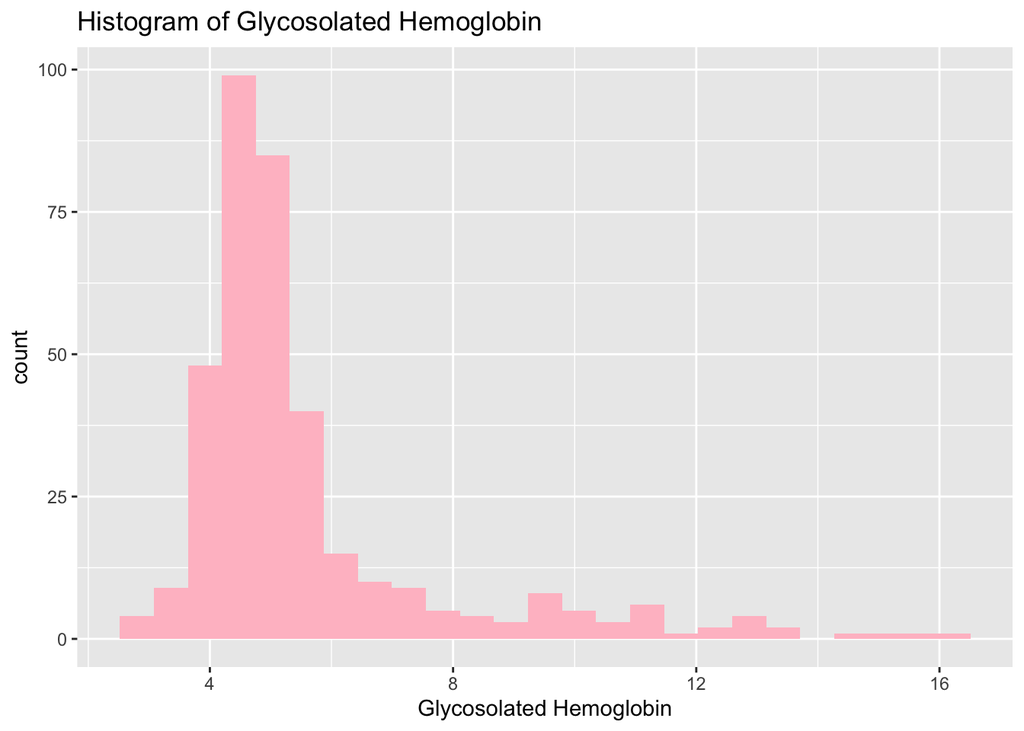

```r
diabetes_clean %>% ggplot(aes(glyhb))+ geom_histogram(bins=25, fill='pink') +labs(title="Histogram of Glycosolated Hemoglobin",x='Glycosolated Hemoglobin')
```

The variable ‘glyhb_star’ was created by taking the log and is plotted in the following to show its new distribution:

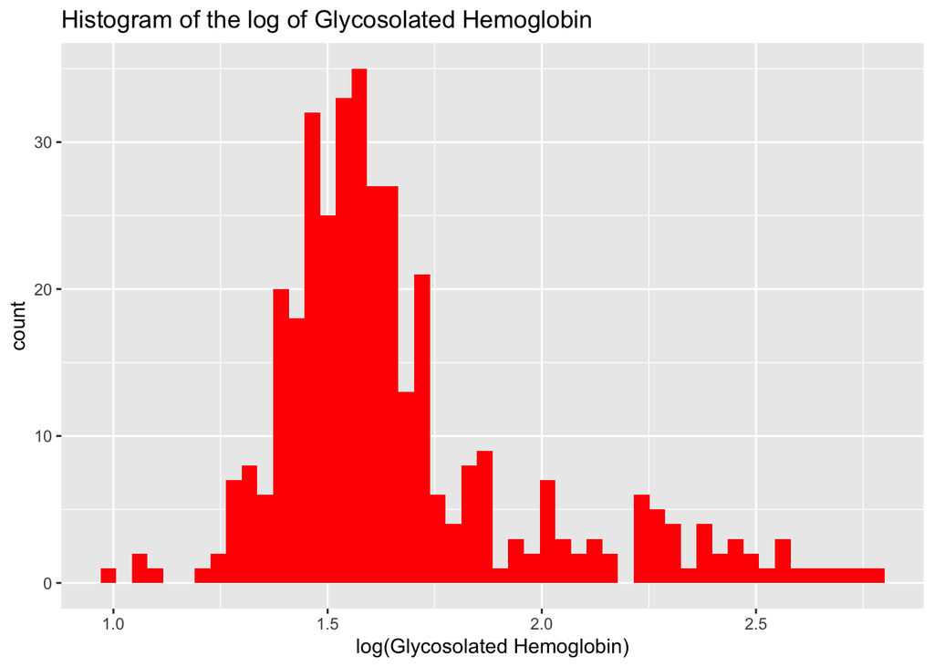

```r
diabetes_clean$glyhb_star = log(diabetes_clean$glyhb)
diabetes_clean %>% ggplot(aes(glyhb_star))+ geom_histogram(bins=50,fill='red')+labs(title="Histogram of the log of Glycosolated Hemoglobin",x='log(Glycosolated Hemoglobin)')
```

Summary statistics were computed. The following table shows a larger mean glyhb value for a larger frame.

```r
diabetes_clean %>% group_by(frame) %>% summarise(mean.glyhb = mean(glyhb_star))
```

```
## # A tibble: 3 x 2
##   frame  mean.glyhb
##   <fct>       <dbl>
## 1 large        1.75
## 2 medium       1.67
## 3 small        1.58
```

The following table shows only a slightly greater mean glyhb for males than females.

```r
diabetes_clean %>% group_by(gender) %>% summarise(mean.glyhb = mean(glyhb_star))
```

```
## # A tibble: 2 x 2
##   gender mean.glyhb
##   <fct>       <dbl>
## 1 female       1.65
## 2 male         1.69
```

The following table shows only a slightly greater mean glyhb for the location Buckingham than Louisa.

```r
diabetes_clean %>% group_by(location) %>% summarise(mean.glyhb = mean(glyhb_star))
```

```
## # A tibble: 2 x 2
##   location   mean.glyhb
##   <fct>           <dbl>
## 1 Buckingham       1.69
## 2 Louisa           1.65
```

## Visualizations

The following is a plot showing the summarized data of `diabetes_clean` grouped by frame and location.

```r
diabetes_clean %>% group_by(frame,location) %>% summarise (mean.glyhb_star= mean(glyhb_star))
```

```
## # A tibble: 6 x 3
## # Groups:   frame [3]
##   frame  location   mean.glyhb_star
##   <fct>  <fct>                <dbl>
## 1 large  Buckingham            1.80
## 2 large  Louisa                1.69
## 3 medium Buckingham            1.71
## 4 medium Louisa                1.64
## 5 small  Buckingham            1.52
## 6 small  Louisa                1.62
```

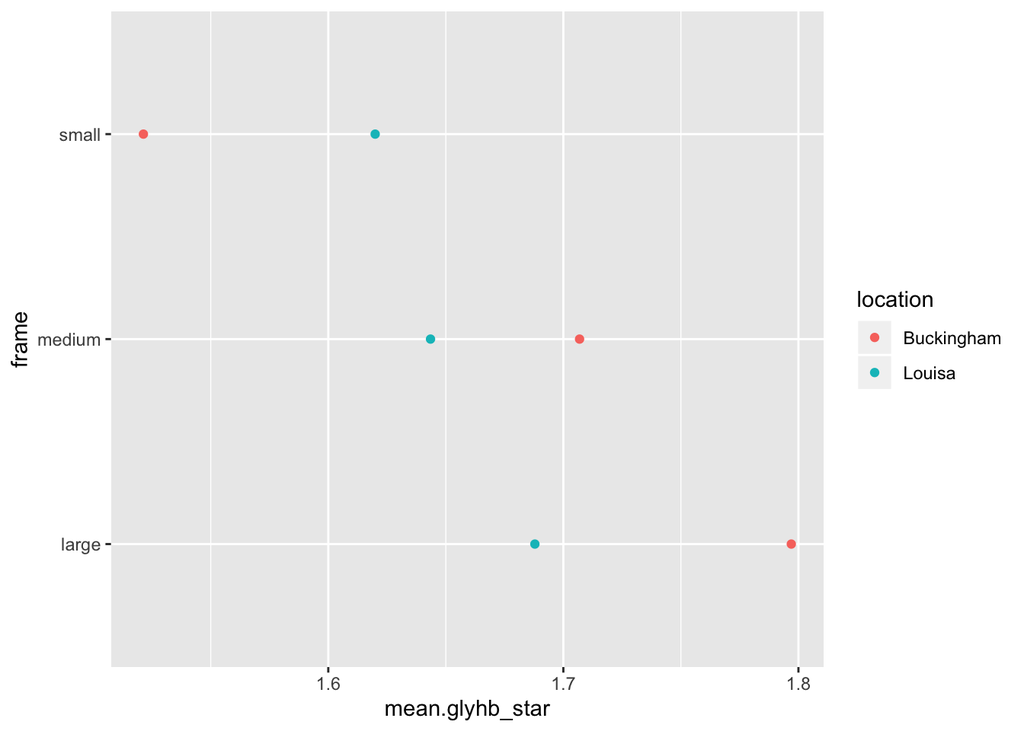

```r
diabetes_clean %>%
  group_by(frame, location) %>%
  summarise (mean.glyhb_star= mean(glyhb_star)) %>%
  ggplot(aes(x = frame, y = mean.glyhb_star, color=location)) + geom_point() + coord_flip()
```

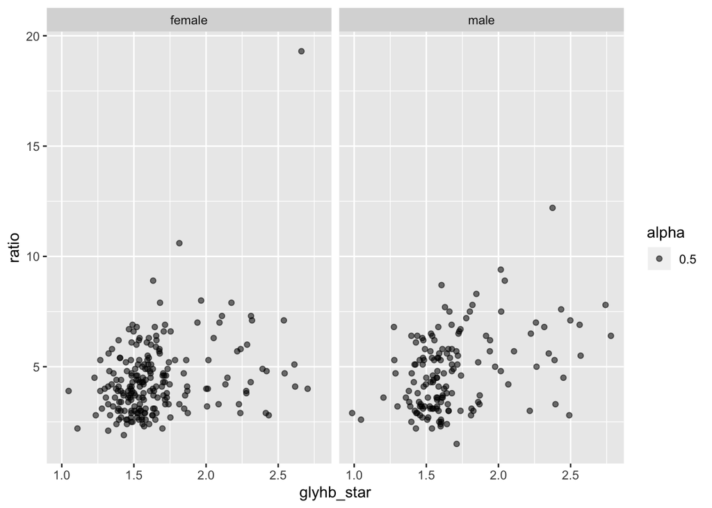

```r
ggplot(diabetes_clean,aes(x=glyhb_star,y=ratio,alpha=0.5)) + geom_point() + facet_wrap(~gender)
```

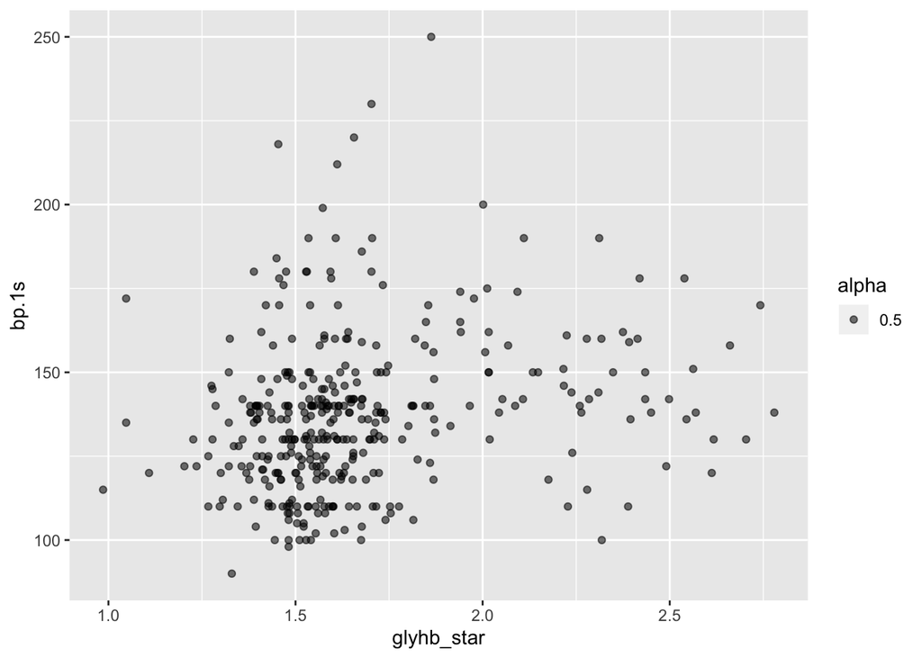

```r
ggplot(diabetes_clean,aes(x=glyhb_star,y=bp.1s,alpha=0.5)) + geom_point()
```

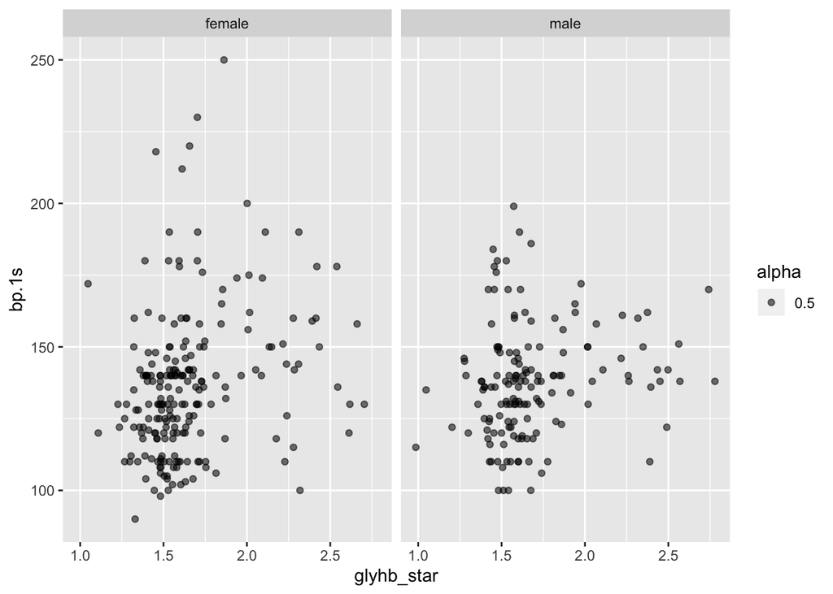

```r
ggplot(diabetes_clean,aes(x=glyhb_star,y=bp.1s,alpha=0.5)) + geom_point() + facet_wrap(~gender)
```

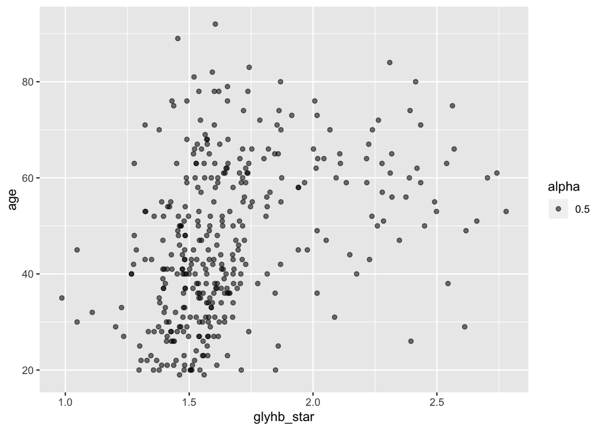

```r
ggplot(diabetes_clean,aes(x=glyhb_star,y=age,alpha=0.5)) + geom_point()
```

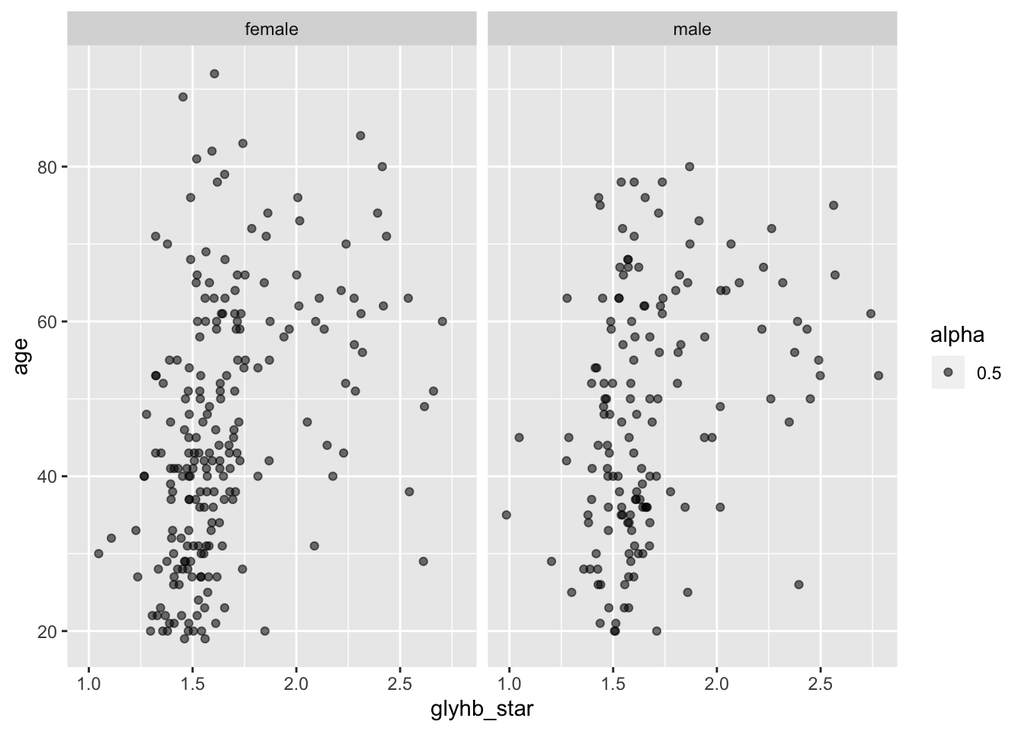

```r
ggplot(diabetes_clean,aes(x=glyhb_star,y=age,alpha=0.5)) + geom_point() + facet_wrap(~gender)
```

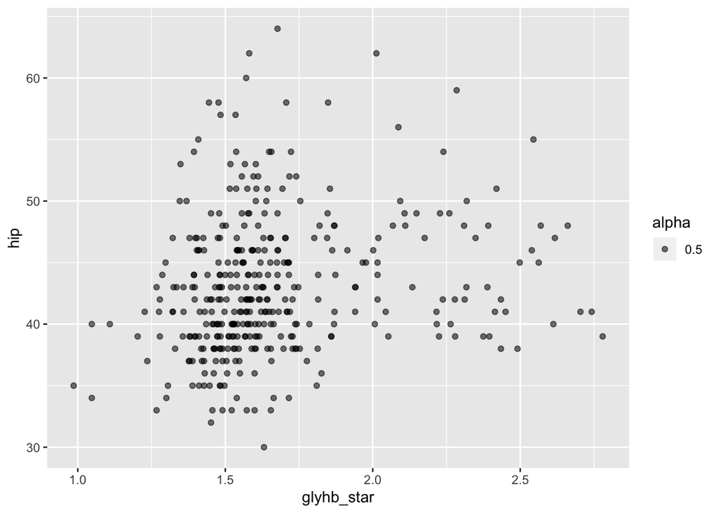

```r
ggplot(diabetes_clean,aes(x=glyhb_star,y=hip,alpha=0.5)) + geom_point()
```

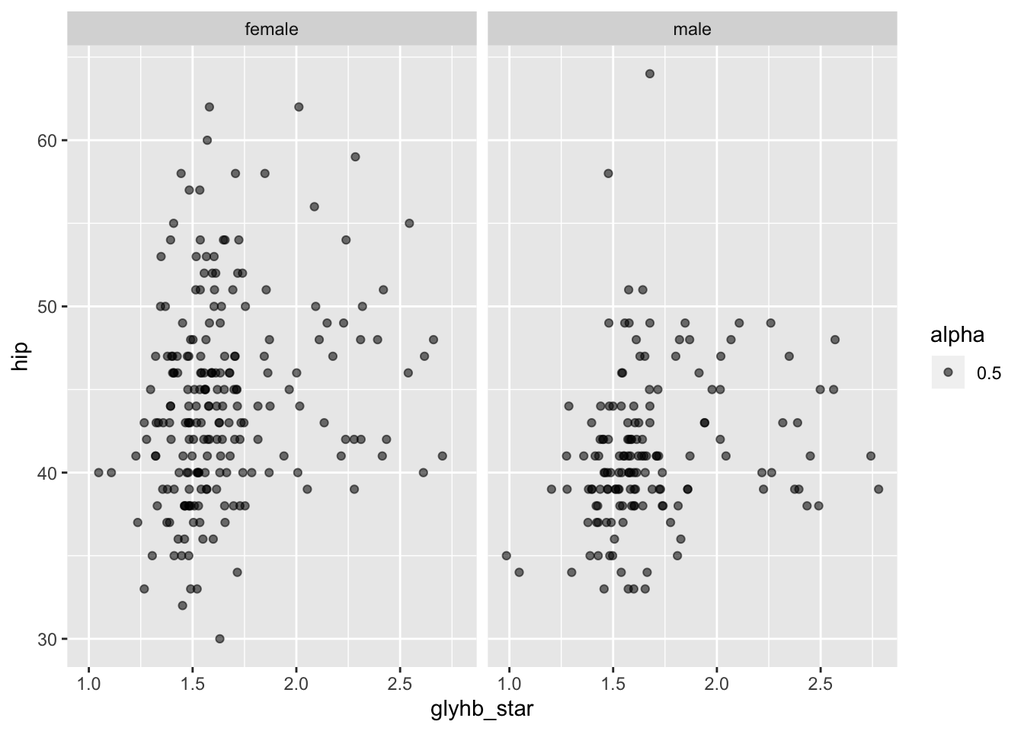

```r
ggplot(diabetes_clean,aes(x=glyhb_star,y=hip,alpha=0.5)) + geom_point() + facet_wrap(~gender)
```

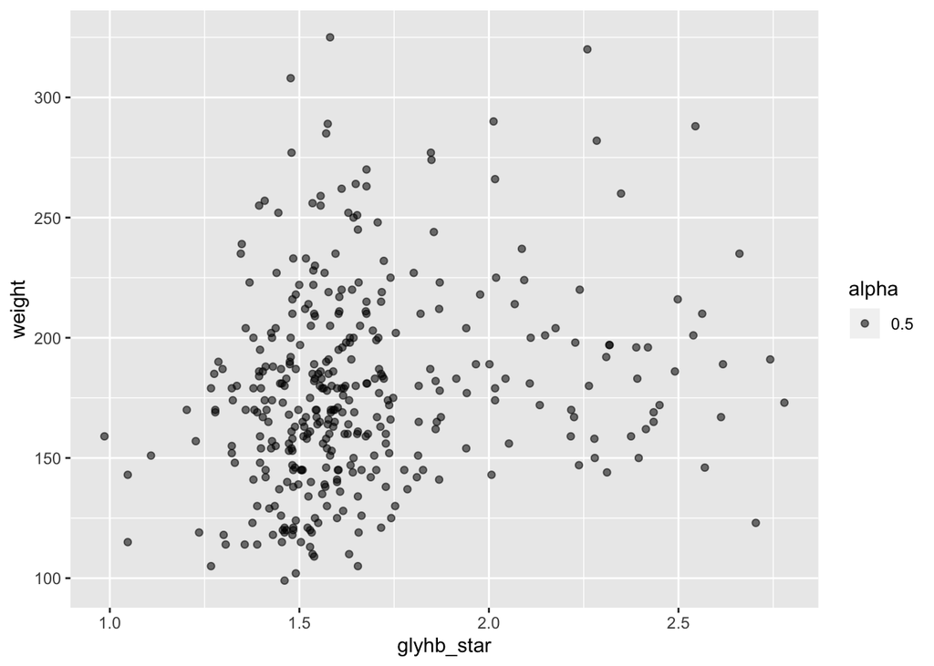

```r
ggplot(diabetes_clean,aes(x=glyhb_star,y=weight,alpha=0.5)) + geom_point()
```

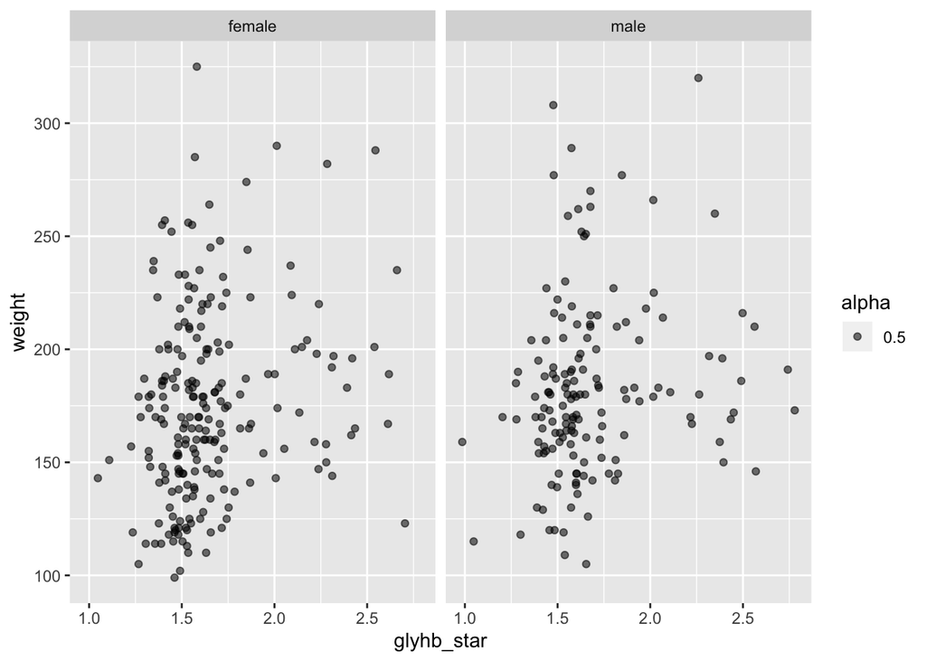

```r
ggplot(diabetes_clean,aes(x=glyhb_star,y=weight,alpha=0.5)) + geom_point() + facet_wrap(~gender)
```

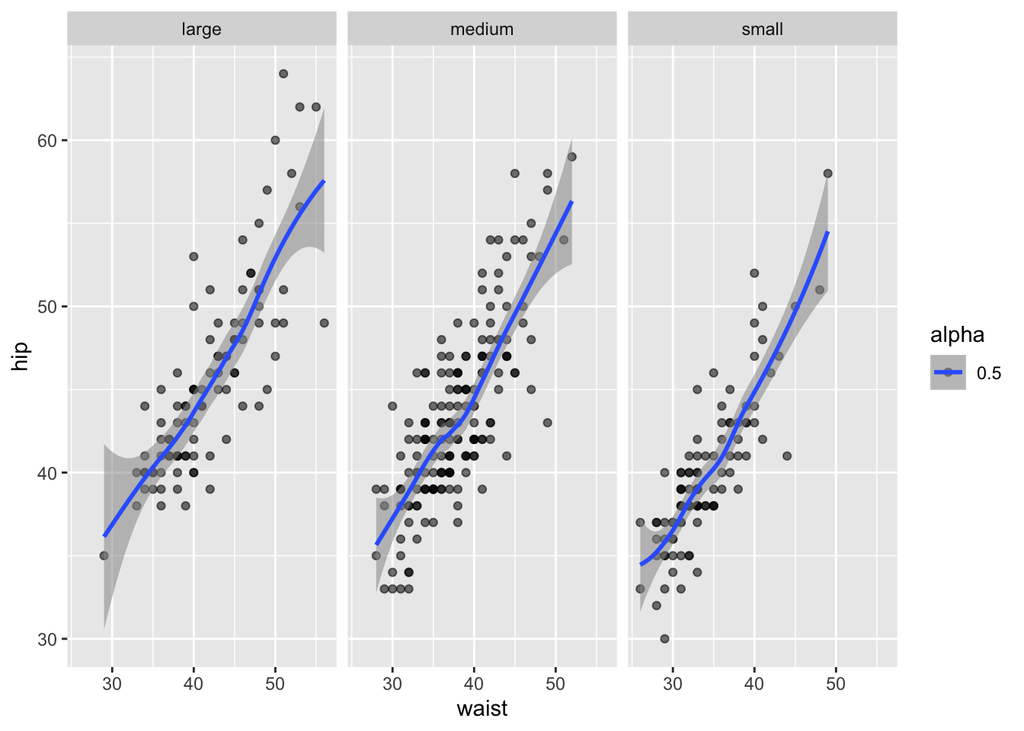

```r
ggplot(diabetes_clean,aes(y=hip,x=waist,alpha=0.5)) + geom_point() + geom_smooth() + facet_wrap(~frame)
```

Another way to visualize the plot would be to create a density plot to show the pattern of the data.

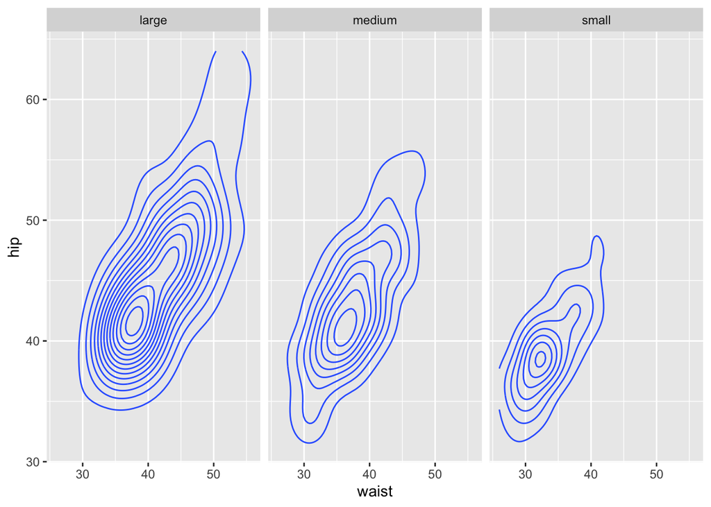

```r
ggplot(diabetes_clean, aes(y=hip, x=waist)) + geom_density_2d() + facet_wrap(~frame)
```

## Messy Data

`gather` and `spread` reshape the data. `spread` copies your data set removing the key and value columns, and replaces them by adding a new column for each unique value of the key column. `gather`, in a way, reverses the `spread` function by collecting a set of column names and replacing them with two columns. These two columns contain the now deleted column names and a column that contains the values of the deleted columns.

No, the functions `spread` and `gather` are not exact complements of each other, because column type information gets lost when using the functions. `gather` discards the original column types and changes the variables into a single vector with one type. By using the `spread` function afterward, we spread the data frame back out and the funtion does not know the original data types of the variables.

## Regression Models

```r
fit = lm(glyhb_star ~stab.glu + age + waist + ratio+ factor(frame),data=diabetes_clean)
 summary(fit)
```

```
##
## Call:
## lm(formula = glyhb_star ~ stab.glu + age + waist + ratio + factor(frame),
##     data = diabetes_clean)
##
## Residuals:
##     Min      1Q  Median      3Q     Max
## -1.0548 -0.1176 -0.0123  0.1020  1.0613
##
## Coefficients:
##                      Estimate Std. Error t value Pr(>|t|)
## (Intercept)         0.8330897  0.0984743   8.460 6.86e-16 ***
## stab.glu            0.0035182  0.0002200  15.992  < 2e-16 ***
## age                 0.0033632  0.0007144   4.708 3.58e-06 ***
## waist               0.0047925  0.0022352   2.144  0.03270 *
## ratio               0.0219341  0.0068169   3.218  0.00141 **
## factor(frame)medium 0.0309167  0.0283657   1.090  0.27648
## factor(frame)small  0.0131840  0.0351518   0.375  0.70784
## ---
## Signif. codes:  0 '***' 0.001 '**' 0.01 '*' 0.05 '.' 0.1 ' ' 1
##
## Residual standard error: 0.2085 on 359 degrees of freedom
## Multiple R-squared:  0.5643, Adjusted R-squared:  0.557
## F-statistic: 77.49 on 6 and 359 DF,  p-value: < 2.2e-16
```

The following are interpretaions of the estimated regression coefficients.

- The average estimated value for glyhb_star with a large frame and all other variables being zero is ‘0.8330’.
- The average estimated value for glyhb_star with a medium frame and all other variables being zero is ‘0.8639’.
- The average estimated value for glyhb_star with a small frame and all other variables being zero is ‘0.8461’.
- For each increase of one unit of ‘stab.glu’ the average glyhb_star value with a large frame will increase by ‘0.0035’, keeping all other variables constant.
- For each increase of one unit of ‘age’ the average glyhb_star value with a large frame will increase by ‘0.0033’, keeping all other variables constant.
- For each increase of one unit of ‘waist’ the average glyhb_star value with a large frame will increase by ‘0.0047’, keeping all other variables constant.
- For each increase of one unit of ‘ratio’ the average glyhb_star value with a large frame will increase by ‘0.0219’, keeping all other variables constant.

Our model estimated fitted values are estimates of the true average of individuals with those observed variables. Using our model, the following is the estimated average glyhb_star value for an individual with these statistics, stab.glu = 90, age = 35, waist = 30, ratio = 5.1, and frame = small.

```r
new.values=data.frame( stab.glu =c(90), age=c(35), waist=c(30), ratio=c(5.1), frame=c('small'))

predict(fit,new.values)
```

```
##       1
## 1.53626
```

The difference between inference and prediction is what we plan to get out of our model. For inference, we hope to understand our data we have already seen. For prediction, we hope to predict the outcome for data we have never seen.

The adavantage of using a linear regression model is that it is very simple opposed to a k-NN regression model. This makes it easily interpreted. However, this could be a great disadvantage by over generalizing our data and introducing a large bias.

## Reflection

We still consider data science to be a field for analyzing and exploring the massive amounts of information we have in today’s age. We have found that most surprisingly, the field is still very new and changing every day. Most fields in university are set in their base knowledge and remain unchanging, but learning that R is open sourced and ever growing is very interesting. We are most challenged by the sheer amount of concepts to be learned in data science, and the amount of different ways to approach a challenge. Finding the best way to approach an issue is the biggest challenge, and the most enjoyable part of data science.